# Integrating Electrophysiological and Transcriptomic Profiles to Differentiate Spiny and Aspiny Dendritic Neurons in the Human Cortex

## Team Member Names & Contributions

- Shriya Krishna: A17367057. Data visualization, data anaysis, figure captions
- Lindsey Crankshaw: A16803811. Finding datasets, data wrangling, data visualization, commenting on code, figure captions
- Niha Ghosh: A16886712. Writing background, question, and discussion.

## Abstract

This study investigates whether electrophysiological properties and gene expression profiles differ significantly between spiny and aspiny dendritic neurons in the human cortex. Using electrophysiological data from the Allen Cell Types Database and microarray gene expression data on ligand-gated ion channels, we compared features such as input resistance, rheobase, and membrane potential. Our analysis revealed significant differences in input resistance and current injection thresholds. These findings highlight how dendritic morphology influences neuronal excitability.

## Research Question

Do electrophysiological properties differ significantly between human cortical spiny and aspiny dendritic neurons, and can variations in gene expression of a cortical region explain functional differences in excitability and synaptic integration?

# Background and Prior Work

Neurons have a vast array of physical and chemical differences. They can vary in axon length, whether they are excitatory or inhibitory, and their dendritic branching patterns. One of the most significant morphological differences is the presence or absence of dendritic spines. These spines are small protrusions from the main dendritic branches and serve as the primary location of excitatory synapses in the mammalian brain (Hering, 2001). While the precise significance of dendritic spines remains under investigation, they are known to play a critical role in synaptic plasticity, influencing processes related to learning and memory. The morphology of these spines is highly dynamic and influenced by the activity of glutamate receptors, which play a central role in excitatory neurotransmission (Hering, 2001). Given that dendritic spines can change in shape and density rapidly in response to synaptic activity, understanding their properties through electrophysiology and gene expression analysis provides valuable insights into the mechanisms underlying neuronal function and plasticity.

A prominent example of spiny neurons is the pyramidal cells found in the cortex. These neurons are characterized by their dense dendritic spines, which are the main targets of excitatory synapses, highlighting their essential role in integrating excitatory inputs and contributing to neural plasticity (Ballesteros-Yáñez et al., 2006). However, dendritic spines are not exclusive to excitatory neurons. Medium Spiny Neurons (MSNs), found in the basal ganglia, are a notable exception. Despite possessing dense dendritic spines, MSNs are inhibitory neurons. They play a critical role in motor control and are implicated in Parkinson’s disease. In Parkinsonian conditions, the loss of dopaminergic input to MSNs leads to a significant decrease in the number of dendritic spines, which disrupts their ability to integrate excitatory signals and send downstream inhibitory outputs (Deutch et al., 2007). This demonstrates that dendritic spine density is not strictly tied to excitatory functions and that the relationship between morphology and neuronal function is complex.

Previous research has primarily focused on the role of dendritic spines in specific neuron types or in relation to particular brain functions and diseases. While the involvement of spines in synaptic plasticity and neurological disorders like Parkinson’s disease has been well-documented, fewer studies have conducted a direct comparison of electrophysiological properties and gene expression profiles between spiny and aspiny neurons. Given the significant functional diversity of these neurons, exploring how dendritic morphology correlates with electrophysiological behavior and gene expression could offer new insights into neural circuit dynamics and disease mechanisms.

To investigate these differences, we utilized publicly available datasets that provided comprehensive electrophysiological and gene expression data. The Allen Cell Types Database includes patch-clamp electrophysiological recordings from human cortical neurons, providing detailed measurements of properties such as input resistance, rheobase, membrane potential, and firing thresholds across neurons categorized by dendritic morphology: spiny, aspiny, and sparsely spiny. The dataset was filtered to isolate neurons based on their dendritic types, enabling a direct comparison of their electrophysiological characteristics. This database allowed us to analyze over 300 neurons from various cortical regions, from which we focused on the middle temporal gyrus (MTG).

For the gene expression analysis, we focused on ligand-gated ion channel activity using human microarray data from the MTG from the ALlen Brain Atlas. The dataset includes expression levels of key genes related to glutamate receptors (GRIA1), GABA receptors (GABRB2), and potassium channels (KCNQ2). Expression data were collected from six subjects. The integration of gene expression and electrophysiological data allowed us to explore potential genetic profiles underlying the observed functional differences between spiny and aspiny neurons.

By combining these datasets, we were able to examine both the functional electrophysiological differences and gene expression profiles of spiny and aspiny neurons, offering a comprehensive perspective on how dendritic structure influences neuronal electrophysiological properties.

## Hypothesis

H₀ (Null Hypothesis): There is no significant difference in the electrophysiological properties of spiny and aspiny neurons. Gene expression in the MTG, where most spiny/aspiny neurons were recorded from, will not show any difference in ligand gated ion channel gene expression.

H₁ (Alternative Hypothesis): Spiny and aspiny neurons exhibit distinct electrophysiological behaviors. Gene expression in the MTG, where most spiny/aspiny neurons were recorded from, will show difference in ligand gated ion channel gene expression that may relate to the distinct electrophysiological properties.

## Setup

*Are there packages that need to be imported, or datasets that need to be downloaded?*

```python
import pandas as pd
pd.set_option('display.max_columns', None,
              'display.max_rows', None)
import numpy as np
import matplotlib.pyplot as plt
import seaborn as sns
from scipy.stats import ttest_ind
from scipy import stats
from allensdk.core.cell_types_cache import CellTypesCache
from allensdk.api.queries.cell_types_api import CellTypesApi
```

## Data Wrangling

To analyze the electrophysiological properties of spiny and aspiny neurons, we used data from the Allen Cell Types Database, accessed via the AllenSDK. We first initialized the CellTypesCache to retrieve metadata and electrophysiological features for human cortical neurons. Using the get_cells() function, we extracted cell metadata, including species, dendritic morphology, and cortical region. Electrophysiological data such as input resistance, rheobase, and membrane potential were retrieved separately using the get_ephys_features() function.

Once both datasets were obtained, we converted them into pandas DataFrames and indexed them by cell ID and specimen ID to ensure proper alignment. These DataFrames were then merged to create a comprehensive dataset containing both cell type information and electrophysiological properties for further analysis. After merging, we filtered the dataset to isolate neurons based on their dendritic morphology, specifically focusing on spiny, aspiny, and sparsely spiny neurons. Spiny neurons, typically excitatory, are characterized by the presence of dendritic spines, while aspiny neurons are primarily inhibitory and lack these structures. We excluded sparsely spiny neurons from our main analysis to maintain a clear distinction between the two major categories.

To ensure data completeness, we identified and removed columns with missing values (NaNs) in either spiny or aspiny neurons. Columns containing NaNs were excluded to prevent bias and ensure a consistent dataset for statistical comparisons. This process resulted in two clean datasets: clean_spiny_df and clean_aspiny_df, each containing neurons with complete electrophysiological data. Finally, we isolated the MTG neurons specifically as they composed most of the dataset and provided regional specifity for microarray gene analysis.

This data wrangling process was essential to prepare a structured and high-quality dataset for analysis, allowing us to explore the relationship between dendritic morphology and electrophysiological properties in human cortical MTG neurons.

```python
# Initialize the CellTypesCache to access Allen Brain Atlas data
ctc = CellTypesCache(manifest_file='cell_types/manifest.json')

# get human cells
human_cells = ctc.get_cells(species=[CellTypesApi.HUMAN])

# Retrieve metadata for human cortical neurons
# This includes information about
# neuron types, species, and dendritic morphology
cells_df = pd.DataFrame(human_cells)
cells_df = cells_df.set_index('id')

# Retrieve electrophysiological features for all neurons
# This includes properties like
# input resistance, rheobase, and membrane potential
ephys = ctc.get_ephys_features()
ephys_df = pd.DataFrame(ephys)
ephys_df = ephys_df.set_index('specimen_id')

# Save a list of all electrophysiological feature columns
ephys_features = ephys_df.columns.tolist()

# Remove non-electrophysiological columns (e.g., IDs)
# This ensures we're only analyzing relevant properties
# like input resistance and firing thresholds
for col in ephys_features:
    if 'id' in col:
        ephys_features.remove(col)

# Merge the cell metadata with electrophysiological features
# using specimen ID
ephys_df = cells_df.join(ephys_df)

# Filter neurons by dendrite type to
# isolate spiny, aspiny, and sparsely spiny neurons
spiny_ephys_df = ephys_df[ephys_df['dendrite_type'] == 'spiny']
aspiny_ephys_df = ephys_df[ephys_df['dendrite_type'] == 'aspiny']
sparsely_spiny_ephys_df = ephys_df[
    ephys_df['dendrite_type'] == 'sparsely spiny']

# Identify columns with missing values (NaNs) in spiny neurons
# This ensures we exclude incomplete data from our analysis
nan_cols = []
for col in ephys_features:
    if spiny_ephys_df[col].isna().any():
        nan_cols.append(col)

# Repeat the NaN check for aspiny neurons
nan_cols_aspiny = []
for col in ephys_features:
    if aspiny_ephys_df[col].isna().any():
        nan_cols_aspiny.append(col)

# Combine NaN columns from
# both spiny and aspiny datasets to ensure consistency
for col in nan_cols_aspiny:
    if col not in nan_cols:
        nan_cols.append(col)

# Drop columns with NaN values to create
# clean datasets for spiny and aspiny neurons
clean_spiny_df = spiny_ephys_df.drop(columns=nan_cols)
clean_aspiny_df = aspiny_ephys_df.drop(columns=nan_cols)

# Filter the list of electrophysiological
# features to exclude those with missing data
ephys_features_filtered = ephys_features[:]
for feature in nan_cols:
    ephys_features_filtered.remove(feature)

# Verify that no NaN values remain in
# the filtered electrophysiological features
nan_counts = aspiny_ephys_df[
    ephys_features_filtered].isna().sum()
print(f"Spiny: \n{nan_counts}")
nan_counts = aspiny_ephys_df[
    ephys_features_filtered].isna().sum()
print(f"\nAspiny: \n{nan_counts}")

# Isolate MTG neurons from the spiny and aspiny datasets
MTG_spiny_df = clean_spiny_df[clean_spiny_df[
    'structure_area_abbrev'] == 'MTG']
MTG_aspiny_df = clean_aspiny_df[clean_aspiny_df[
    'structure_area_abbrev'] == 'MTG']
print(MTG_spiny_df['dendrite_type'].value_counts())
print(MTG_aspiny_df['dendrite_type'].value_counts())
```

```
Spiny:
f_i_curve_slope                           0
fast_trough_t_long_square                 0
fast_trough_t_short_square                0
fast_trough_v_long_square                 0
fast_trough_v_short_square                0
has_burst                                 0
has_delay                                 0
has_pause                                 0
input_resistance_mohm                     0
latency                                   0
peak_t_long_square                        0
peak_t_short_square                       0
peak_v_long_square                        0
peak_v_short_square                       0
rheobase_sweep_number                     0
ri                                        0
sag                                       0
seal_gohm                                 0
tau                                       0
threshold_i_long_square                   0
threshold_i_short_square                  0
threshold_t_long_square                   0
threshold_t_short_square                  0
threshold_v_long_square                   0
threshold_v_short_square                  0
trough_t_long_square                      0
trough_t_short_square                     0
trough_v_long_square                      0
trough_v_short_square                     0
upstroke_downstroke_ratio_long_square     0
upstroke_downstroke_ratio_short_square    0
vm_for_sag                                0
vrest                                     0
dtype: int64

Aspiny:
f_i_curve_slope                           0
fast_trough_t_long_square                 0
fast_trough_t_short_square                0
```

[output cut: 20 more lines]

```
threshold_v_long_square                   0
threshold_v_short_square                  0
trough_t_long_square                      0
trough_t_short_square                     0
trough_v_long_square                      0
trough_v_short_square                     0
upstroke_downstroke_ratio_long_square     0
upstroke_downstroke_ratio_short_square    0
vm_for_sag                                0
vrest                                     0
dtype: int64
spiny    236
Name: dendrite_type, dtype: int64
aspiny    61
Name: dendrite_type, dtype: int64
```

After cleaning, we obtained 236 spiny and 61 aspiny neurons with complete electrophysiological data for further analysis.

Next, we loaded in a human microarray gene expression dataset from Allen Brain Atlas that focused on genes related to ligand gated ion channel activity. This dataset contained z score normalized gene expression data, probe information, and region information for six human brains. Based on the prior dataset which indicated MTG to have the largest sample size, this region was focused on as a region of interest for ligand gated ion channel gene expression. The expression for each of the six subjects was averaged in the MTG specifically for all genes. Genes of interest chosen (for their ability to influence electrophysiological properties of interest) and a cleaned dataset of the MTG with specific genes' expression was created.

```python
# import human ligand gated ion channel activity
# microarray expression data from Allen Brain Atlas
LG_exp_df = pd.read_csv(
    'ligand_gated_ion_channel_activity/Expression.csv', header=None)
LG_cols_df = pd.read_csv(
    'ligand_gated_ion_channel_activity/Columns.csv')
LG_probes_df = pd.read_csv(
    'ligand_gated_ion_channel_activity/Probes.csv')

# create a list of region names
regions = LG_cols_df['structure_name'].tolist()
regions.insert(0, 'probe_id')

# set columns to list of region names
LG_exp_df.columns = regions

# set index to probe id
LG_exp_df = LG_exp_df.set_index('probe_id')
LG_probes_df = LG_probes_df.set_index('id')

# join dataframes to include gene name in expression df
LG_exp_df = LG_exp_df.join(LG_probes_df[['gene-name']])

# select only MTG data
MTG_exp_df = LG_exp_df[[
    'middle temporal gyrus', 'gene-name']]

# find mean of expression across six subjects
MTG_exp_df['exp avg'] = MTG_exp_df[
    'middle temporal gyrus'].mean(axis=1)
MTG_exp_df

# select specific genes
gene_names = MTG_exp_df['gene-name'].unique().tolist()
genes_of_interest = ['GABA', 'glutamate', 'potassium']

# loops through genes and adds them to list
genes_filtered = []
for gene in gene_names:
    for item in genes_of_interest:
        if item in gene:
            genes_filtered.append(gene)

# filter data for specific genes
MTG_exp_filtered_genes_df = MTG_exp_df[
    MTG_exp_df['gene-name'].isin(genes_filtered)]
```

## Data Visualization

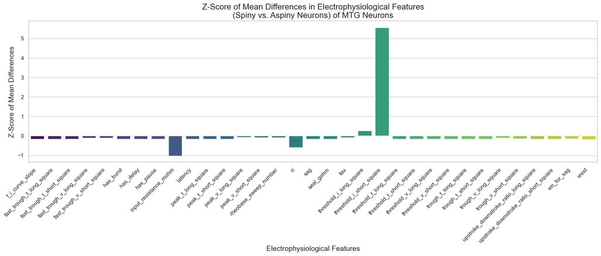

```python
# Create z-score plot of mean differences
# between spiny and aspiny neurons
fig, ax = plt.subplots(figsize=(20, 5))

# Generate list of mean differences
# for electrophysiological features
diff_ephys = []
for col in ephys_features_filtered:
    spiny_mean = MTG_spiny_df[col].mean()
    aspiny_mean = MTG_aspiny_df[col].mean()
    diff_ephys.append(spiny_mean - aspiny_mean)

# Create dictionary for ease of reference
dictionary = dict(zip(
    ephys_features_filtered, diff_ephys))

# Generate z-scores for the differences
diff_zscore = stats.zscore(diff_ephys)

# Plot the bar plot with consistent
# color scheme using seaborn's 'viridis' palette
sns.barplot(x=ephys_features_filtered,
            y=diff_zscore,
            palette='viridis',
            ax=ax)

# Add plot title and axis labels
ax.set_title(
    'Z-Score of Mean Differences in Electrophysiological Features\n(Spiny vs. Aspiny Neurons) of MTG Neurons',
             fontsize=16)
ax.set_xlabel('Electrophysiological Features',
              fontsize=14)
ax.set_ylabel('Z-Score of Mean Differences',
              fontsize=14)

# Rotate x-axis labels for readability
plt.xticks(rotation=45, ha="right")

# Display the plot
plt.show()
```

This bar plot shows the z-scores of mean differences in electrophysiological properties between spiny and aspiny neurons. Positive values indicate higher measurements in spiny neurons, while negative values indicate higher measurements in aspiny neurons. Four metrics stand out: input_resistance_mohm and ri seem lower in spiny neurons of the MTG while threshold_i_long_square and threshold_i_short_square seem higher in spiny neurons of the MTG.

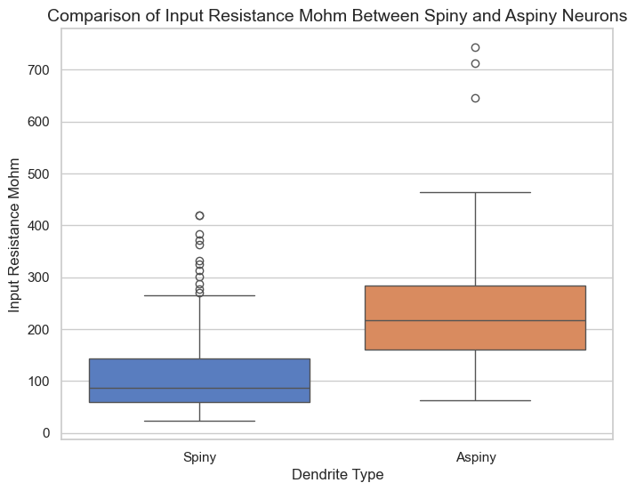

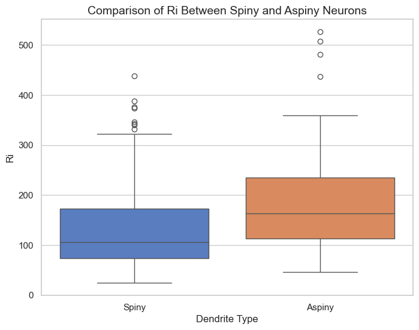

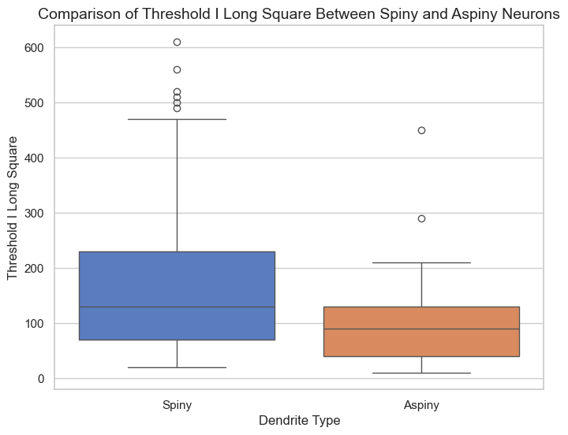

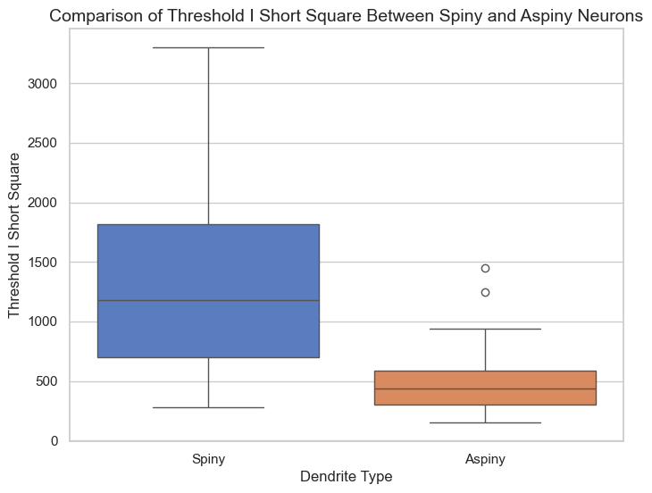

```python
# Plot Boxplots of Electrophysiological
# Features of Interest

# Add dendrite type column to each DataFrame
MTG_spiny_df['dendrite_type'] = 'Spiny'
MTG_aspiny_df['dendrite_type'] = 'Aspiny'

# Combine both DataFrames for plotting
MTG_combined_df = pd.concat([
    MTG_spiny_df, MTG_aspiny_df], ignore_index=True)

# Create list of electrophysiological features of interest
ephys_features_of_interest = [
    'input_resistance_mohm',
    'ri',
    'threshold_i_long_square',
    'threshold_i_short_square'
    ]

# Generate boxplots for each feature
for feature in ephys_features_of_interest:
    plt.figure(figsize=(8, 6))

    # Plot with consistent color palette
    sns.boxplot(
        data=MTG_combined_df,
        x='dendrite_type',
        y=feature,
        palette='muted')

    # Add title and labels
    plt.title(
        f'Comparison of {feature.replace("_", " ").title()} Between Spiny and Aspiny Neurons',
        fontsize=14)
    plt.xlabel('Dendrite Type', fontsize=12)
    plt.ylabel(
        f'{feature.replace("_", " ").title()}',
        fontsize=12)

    # Display plot
    plt.show()
```

The input resistance is lower for spiny neurons compared to aspiny, which reflects their morphology and surface area. The ri, a similar metric computed from current clamp instead of votlage clamp, is also lower for spiny neurons compared to aspiny, similarly related to their morphology. Threshold i long square is higher in spiny neurons which indicates that they have a higher threshold for longer current stimuli and thus are less excitable. This is also seen in the threshold i short square, which is a brief current, and the difference between spiny and aspiny is more prominent.

An interesting finding emerged with threshold_i_short_square, where lower values were observed in aspiny neurons within the MTG. Since lower threshold currents indicate increased neuronal excitability, this suggests that aspiny neurons in the MTG may exhibit greater excitability than previously thought, despite their traditional inhibitory roles.

This regional analysis provides a deeper understanding of how dendritic morphology and electrophysiological properties interact within the MTG.

## Data Analysis & Results

We analyzed electrophysiological properties and gene expression profiles to compare spiny and aspiny dendritic MTG neurons. T-tests revealed significant differences in input resistance, resting input (ri), and threshold currents, indicating distinct excitability profiles between the two neuron types. Complementing this, gene expression analysis from the MTG was analyzed for any expression level changes in the MTG that may be associated with the electrophysiological properties. These findings highlight the interplay between dendritic morphology, molecular profiles, and neuronal function.

A t-test was performed to compare the input resistance between spiny and aspiny MTG neurons. The results showed a significant differences between the two groups for the four electrophysiological properties. Specifically, aspiny neurons exhibited higher input resistance compared to spiny neurons (indpendent t-test: T = -7.03, p = .0000). This suggests that spiny neurons have lower input resistance compared to aspiny and thus morphologically may be different in their surface area or ion channel composition. Resting input (ri) was also significantly lower in spiny neurons (indpendent t-test: T = -4.27, p = 0.0001), further indicating similar morphological differences.

Interestingly, spiny neurons required higher threshold currents to initiate action potentials. For long square pulse thresholds, spiny neurons exhibited significantly higher values compared to aspiny neurons (indpendent t-test: T = 5.10, p = 0.0000). This trend was even more pronounced for short square pulse thresholds (indpendent t-test: T = 14.72, p = 0.0000), suggesting that spiny neurons have lower excitability compared to aspiny neurons in the MTG.

These findings strongly support our hypothesis that morphological differences in dendritic structures are associated with distinct electrophysiological properties. The combination of lower input resistance and higher threshold currents in spiny neurons gives insight to the morphology and electrophysiological properties that seperate them from aspiny neurons.

```python
# Perform t-tests for electrophysiological
# features of interest

# Create a list of features
features = ['input_resistance_mohm',
            'ri',
            'threshold_i_long_square',
            'threshold_i_short_square']

# Perform t-tests for each feature
for feature in features:
    # Extract data for spiny and aspiny neurons
    spiny_data = MTG_spiny_df[feature]
    aspiny_data = MTG_aspiny_df[feature]

    # Perform t-test
    t_stat, p_value = ttest_ind(
        spiny_data,
        aspiny_data,
        equal_var=False
        )

    # Display the results
    print(
        f"T-test results for {feature.replace('_', ' ')}:")
    print(
        f"T-statistic = {t_stat:.2f}, p-value = {p_value:.4f}")

    # Interpretation
    if p_value < 0.05:
        print(
            f"The difference in {feature.replace('_', ' ')} between spiny and aspiny neurons is statistically significant (*p* < 0.05).\n")
    else:
        print(
            f"There is no statistically significant difference in {feature.replace('_', ' ')} between spiny and aspiny neurons (*p* >= 0.05).\n")
```

```
T-test results for input resistance mohm:
T-statistic = -7.03, p-value = 0.0000
The difference in input resistance mohm between spiny and aspiny neurons is statistically significant (*p* < 0.05).

T-test results for ri:
T-statistic = -4.27, p-value = 0.0001
The difference in ri between spiny and aspiny neurons is statistically significant (*p* < 0.05).

T-test results for threshold i long square:
T-statistic = 5.10, p-value = 0.0000
The difference in threshold i long square between spiny and aspiny neurons is statistically significant (*p* < 0.05).

T-test results for threshold i short square:
T-statistic = 14.72, p-value = 0.0000
The difference in threshold i short square between spiny and aspiny neurons is statistically significant (*p* < 0.05).
```

Gene expression was visualized by barplot of z scored expression levels for the genes of interest in the MTG. Significance of gene expression was set to |Z| > 2, as reported by prior literature on microarray gene expression data that had been z scored (Cheadle et al., 2003).

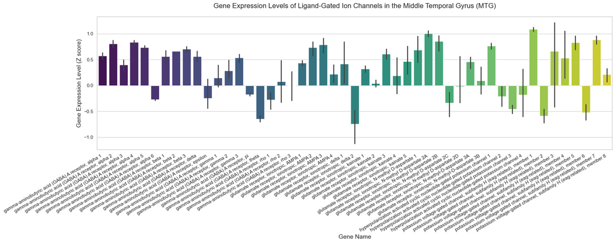

```python
# Set seaborn style
sns.set(style="whitegrid")

# Increase figure size for better spacing
fig, ax = plt.subplots(figsize=(20, 8))

# Plot the gene expression with simplified gene names
sns.barplot(data=MTG_exp_filtered_genes_df,
            x='gene-name',
            y='exp avg',
            palette='viridis',
            ax=ax)

# Add title and axis labels
ax.set_title(
    'Gene Expression Levels of Ligand-Gated Ion Channels in the Middle Temporal Gyrus (MTG)',
    fontsize=16,
    pad=20)
ax.set_xlabel('Gene Name',
              fontsize=14)
ax.set_ylabel('Gene Expression Level (Z score)',
              fontsize=14)

# Rotate x-axis labels
plt.xticks(rotation=30, ha="right")

# Adjust layout to prevent label cutoff
plt.tight_layout()

# Display the plot
plt.show()
```

Gene expression analysis from the MTG were not significanlty altered but offered some insights. Glutamate receptor genes (such as AMPA 1-4 and NMDA receptor subunits) showed moderate to elevated expression, aligning with the role of spiny neurons in facilitating excitatory neurotransmission. GABA neurons also showed some elevation, accounting for often inhibitory aspiny neurons.

Furthermore, potassium channel-related genes exhibited variable expression patterns, with some subtypes showing elevated expression. These variations may contribute to the distinct firing thresholds observed in the electrophysiological data, potentially influencing neuronal excitability in both spiny and aspiny neurons.

Despite these trend level differences, none of the genes expression levels were higher than 2 z scores, indicating they were not significantly different from other regions. If the findings were more pronounced, they may partially support our hypothesis that structural differences in dendritic morphology are reflected in gene expression patterns, however the lack of signifcance prevents any meaningful analysis of the pattern of expression seen.

## Conclusion & Discussion

Gene expression data from the middle temporal gyrus (MTG) did not provide significant results. Receptors would have to show a z-score of more than 2 to be significant and most findings were within 1 z-score. Additionally, the data set did not specify between spiny and aspiny neurons, so we would be unable to form any definitive conclusions about gene expression and their connection to the different neurons. When performing the analysis, we hypothesized that if glutamate receptors displayed a significant expression, they could be connected to spiny neurons, which are mostly excitatory. Conversely, if GABA receptors displayed a significant expression, they could be connected to aspiny neurons, which are mostly inhibitory. Further exploration would be needed to make these conclusions.

While performing our analysis, we ran into several limitations. The dataset was restricted to specific cortical regions, primarily the MTG, which may limit the generalizability of our findings across the entire brain. Furthermore, while we focused on ligand-gated ion channel gene expression, other molecular factors, such as epigenetic modifications or proteomic differences, were not explored and may also contribute to the observed electrophysiological differences.

Future analyses could expand this research by incorporating connectivity data from the Allen Connectivity Database to examine how structural and functional differences in spiny and aspiny neurons influence broader neural circuits. Additionally, integrating patch sequencing data could provide more granular insights into gene expression variability specifically for spiny vs aspiny neurons. Finally, investigating these neuronal differences in the context of neurological disorders (e.g., epilepsy, schizophrenia) could help elucidate how disruptions in excitatory-inhibitory balance contribute to disease pathology. To achieve this, datasets that include disease models or patient-derived samples would be essential for drawing clinically relevant conclusions.

### References (include links):

Ballesteros-Yáñez, I., Benavides-Piccione, R., Elston, G. N., Yuste, R., & DeFelipe, J. (2006). Density and morphology of dendritic spines in mouse neocortex. Neuroscience, 138(2), 403–409. https://doi.org/10.1016/j.neuroscience.2005.11.038

Cheadle, C., Vawter, M. P., Freed, W. J., & Becker, K. G. (2003). Analysis of microarray data using Z score transformation. The Journal of molecular diagnostics : JMD, 5(2), 73–81. https://doi.org/10.1016/S1525-1578(10)60455-2

Deutch, A. Y., Colbran, R. J., & Winder, D. J. (2007). Striatal plasticity and medium spiny neuron dendritic remodeling in parkinsonism. Parkinsonism & Related Disorders, 13(Suppl. 3), S251–S258. https://doi.org/10.1016/S1353-8020(08)70012-9

Hering, H., & Sheng, M. (2001). Dendritic spines: Structure, dynamics and regulation. Nature Reviews Neuroscience, 2(12), 880–888. https://doi.org/10.1038/35104061